# Ανάλυση Επιβίωσης στον Καρκίνο του Μαστού

Νικόλαος Τζούρας

16/9/2025

## 1. Εισαγωγή

Καρκίνος είναι μια ομάδα ασθενειών που χαρακτηρίζονται από αφύσικη κυτταρική ανάπτυξη και την εξάπλωση αυτής σε άλλα μέρη του σώματος. Η παρούσα μελέτη επικεντρώνεται ειδικότερα στον **Καρκίνο του Μαστού**.

Είναι ο πιο διαδεδομένος σε γυναικείο πληθυσμό καρκίνος παγκοσμίως. Αποτελεί συνολικά τη δεύτερη αιτία θανάτου των γυναικών από κακοηθές νεόπλασμα και την πρώτη αιτία θανάτου για γυναίκες μεταξύ 45-60 ετών.

Σκοπός της μελέτης είναι η εφαρμογή και αξιολόγηση μεθόδων ανάλυσης επιβίωσης *(survival analysis)* σε ένα προσομοιωμένο σύνολο δεδομένων ασθενών με καρκίνο του μαστού. Το dataset βασίζεται σε επιδημιολογικές κατανομές και στοιχεία από έγκυρες πηγές για τις χρησιμοποιούμενες μεταβλητές. Ειδικότερα, επιδιώκεται η εκτίμηση του χρόνου επιβίωσης, η σύγκριση της επιβίωσης μεταξύ διαφορετικών σταδίων καρκίνου και θεραπευτικών ομάδων, καθώς και η αναγνώριση κλινικών και δημογραφικών παραγόντων που επηρεάζουν τον κίνδυνο θανάτου ή υποτροπής.

### Ερευνητικά ερωτήματα

Βάσει του σκοπού της μελέτης, τα κύρια ερευνητικά ερωτήματα είναι:  
- Ποια δημογραφικά και κλινικά χαρακτηριστικά επηρεάζουν τον χρόνο επιβίωσης των ασθενών και πώς διαφέρουν οι πιθανότητες επιβίωσης μεταξύ διαφορετικών σταδίων της νόσου και θεραπευτικών ομάδων;  
- Ποιοι παράγοντες αποτελούν σημαντικούς προγνωστικούς δείκτες για την επιβίωση, λαμβάνοντας υπόψη την επίδραση των υπόλοιπων μεταβλητών;  
- Υπάρχει αλληλεπίδραση μεταξύ σταδίου καρκίνου και θεραπευτικής ομάδας;  
- Πώς διαφέρει η επιβίωση μεταξύ ανδρών και γυναικών, λαμβάνοντας υπόψη το υπερβολικά μικρό ποσοστό ανδρών στο σετ δεδομένων;

## 2. Δεδομένα

Για την ανάλυση, δημιουργήθηκε ενα προσομοιωμένο σετ δεδομένων, στο προγραμματιστικό περιβάλλον της R, ώστε τα δεδομένα που θα χρησιμοποιηθούν να εκλάβουν ένα ρεαλιστικό πόρισμα για το survival analysis. Η κατασκευή του έγινε με τρόπο ώστε να αντικατοπτρίζει τις κατανομές που παρατηρούνται σε πραγματικές κλινικές μελέτες και εθνικά δεδομένα. Οι μεταβλητές και η προέλευση τους περιγράφονται παρακάτω, μαζί με τις τιμές που χρησιμοποιήθηκαν για την προσομοίωση:

1. **Cancer Stage (Localized, Regional, Distant, Unknown)**: Αντιπροσωπεύει το στάδιο διάγνωσης του καρκίνου, από περιορισμένο τοπικό όγκο έως εκτεταμένες μεταστάσεις. Τα ποσοστά επιλέχθηκαν από την μελέτη American Cancer Society (2024-2025), όπου χρησιμοποιήθηκαν και για τον καθορισμό των συντελεστών κινδύνου, ώστε οι ασθενείς με πιο προχωρημένο στάδιο καρκίνου να εμφανίζουν υψηλότερη πιθανότητα θανάτου.
2. **Start date**: Παρέχει την ημερομηνία διάγνωσης του κάθε ασθενή, και κυμαίνονται με τυχαία κατανομή από 01/01/2020 έως και 16/09/2025, δηλαδή έως και την ημέρα που διεξάχθηκε η παρούσα μελέτη, ώστε να μιμείται πραγματική χρονική κατανομή νέων διαγνώσεων.
3. **Event/Status (Dead/Alive)**: Η μεταβλητή **event** παίρνει τις τιμές 1=θάνατος και 0=ζωντανός, ενώ η ίδια πληροφορία αποδίδεται και στην μεταβλητή **status** (Dead/Alive). Η κατανομή τους προσομοιώθηκε βάσει πιθανοτήτων ανά στάδιο καρκίνου (American Cancer Society 2024-2025).
4. **Time to event**: Μας παρέχει δεδομένα για την διάρκεια μηνών μέχρι ο ασθενής είτε να απεβιώσει είτε να παραμένει ζωντανός στην τελευταία παρακολούθηση. Για κάθε μια κατηγορία υπολογίζεται διαφορετικά. Για ασθενείς που απεβίωσαν προσομοιώνεται με εκθετική κατανομή χρησιμοποιώντας τους συντελεστές κινδύνου που αναφέρθηκαν στο στάδιο διάγνωσης. Ο χρόνος για κάθε στάδιο περιορίζεται με ελάχιστες και μέγιστες τιμές για ρεαλισμό. Ασθενείς που παραμένουν ζωντανοί, έχουν διάρκεια μηνών ίση με τον χρόνο της ημερομηνίας διάγνωσης έως την ημέρα που διεξάχθηκε η έρευνα (16/09/2025).
5. **Event date**: Η ημερομηνία εμφάνισης του γεγονότος (θάνατος ή τελευταία παρακολούθηση). Υπολογίζεται ως: event_date = start_date + time_to_event × 30,416 ημέρες.
6. **Age**: Η ηλικία του ασθενούς κατά τη διάγνωση. Οι τιμές στα δεδομένα κυμαίνονται μεταξύ 40 και 80 ετών, ώστε να αντανακλούν τις ηλικιακές ομάδες όπου εμφανίζεται συχνότερα καρκίνος του μαστού και να αποφευχθούν μη ρεαλιστικές περιπτώσεις θανάτου.
7. **Sex**: Το φύλο του ασθενούς. Βάσει επιδημιολογικών δεδομένων, το 99% των περιστατικών αφορά γυναίκες και το 1% άντρες.
8. **Smoker (Yes/No)**: Καταγράφει αν ο ασθενής είναι καπνιστής. Σύμφωνα με την έκθεση του ΟΟΣΑ για τον καρκίνο στην Ελλάδα (OECD Greece 2025), το 25% του πληθυσμού καπνίζει.
9. **Family history (Yes/No)**: Υποδηλώνει αν ο ασθενής έχει οικογενιακό ιστορικό καρκίνου του μαστού. Βάσει μελέτης Nature (2021), το ποσοστό κυμαίνεται μεταξύ 5-10%, και στην μελέτη προσομοιώθηκε ως 7,5%.
10. **Chemotherapy (Yes/No)**: Καταγράφει αν ο ασθενής έλαβε χημειοθεραπεία. Σύμφωνα με την μελέτη Breast Cancer Research (2024), το αντίστοιχο ποσοστό ανέρχεται σε 38,9%.
11. **Treatment group (Control/Experimental)**: Οι ασθενείς χωρίστηκαν σε δύο θεραπευτικές ομάδες. Η ομάδα *Control* περιλαμβάνει όσους έλαβαν καθιερωμένες θεραπείες (π.χ. χημειοθεραπέια), ενώ η ομάδα *Experimental* περιλαμβάνει ασθενείς που έλαβαν νεότερες , υπό μελέτη θεραπείες. Για λόγους προσομοίωσης, τα ποσοστά κατανεμήθηκαν ισομερώς (50/50).
12. **BMI & BMI_change**: Ο δείκτης μάζας σώματος (Body Mass Index) πριν και μετά τη θεραπεία. Οι αρχικές τιμές κυμαίνονται από 18 έως 40. Η μεταβολή του BMI προσομοιώθηκε με βάση το στάδιο καρκίνου και την ηλικία, σύμφωνα με δημοσιευμένες συσχετίσεις μεταξύ καρκίνου του μαστού, ηλικία και μεταβολών σωματικού βάρους.
13. **Tumor size (cm)**: Αντιπροσωπεύει το μέγεθος του όγκου (σε εκατοστά). Οι μεγαλύτερες διαστάσεις αντιστοιχούν σε ασθενείς με *Distant* στάδιο, ενώ οι μικρότερες σε ασθενείς με *Localized* στάδιο καρκίνου.
14. **Physical activity (Low/Medium/High)**: Φυσική δραστηριότητα ασθενή κατανεμημένη βασισμένη σε πληθυσμιακά δεδομένα για τον ελληνικό πληθυσμό.
15. **ECOG (0-4)**: Δείκτης λειτουργικής κατάστασης ασθενούς (Easter Cooperative Oncology Group Performance Status), όπου *0=πλήρως δραστήριος* και *4=σοβαρά περιορισμένος*. Οι τιμές προσομοιώθηκαν με βάρη ανά στάδιο καρκίνου. Δεν χρησιμοποιήθηκε η κατηγορία 5, καθώς αυτή αντιστοιχεί σε θάνατο, ο οποίος καλύπτεται ήδη από την μεταβλητή **status**.

## 3. Μεθοδολογία

Η ανάλυση πραγματοποιήθηκε στο λογισμικό R με χρήση διάφορων πακέτων και βιβλιοθηκών για γραφική απεικόνιση και έλεγχο παραδοχών.

Ακολουθήθηκαν τα εξής βήματα:

- Εκτίμηση επιβίωσης (Kaplan-Meier): Υπολογίστηκαν καμπύλες Kaplan-Meier για διάφορες υποομάδες ασθενών (φύλο, στάδιο καρκίνου, κάπνισμα κ.λπ.). Οι καμπύλες συνοδεύτηκαν από πίνακες κινδύνου (risk tables) και διαστήματα εμπιστοσύνης 95%.
- Σύγκριση καμπυλών: Εφαρμόστηκε Log-rank test για να εξετάσει αν οι διαφορές μεταξύ ομάδων στις καμπύλες Kaplan-Meier ήταν στατιστικά σημαντικές.
- Μονοπαραγοντικά Μοντέλα Cox (Univariable Cox Regression): Εκτιμήθηκαν χωριστά τα μοντέλα Cox για κάθε ανεξάρτητη μεταβλητή (ηλικία, φύλο, στάδιο καρκίνου, θεραπευτική ομάδα κ.λπ.). Για κάθε μοντέλο αναφέρθηκαν οι Hazard Ratios (HR) με τα αντίστοιχα 95% CI και οι p-values.
- Πολυπαραγοντική Ανάλυση (Multivariable Cox Regression): Δημιουργήθηκε αρχικό πλήρες μοντέλο Cox με όλες τις κλινικές και δημογραφικές μεταβλητές. Έγινε έλεγχος πολυσυγγραμμικότητας με τον δείκτη VIF και χρησιμοποιήθηκε βηματική επιλογή (stepwise selection με AIC) για την επιλογή του βέλτιστου μοντέλου. Τα αποτελέσματα παρουσιάστηκαν μέσω forest plots.
- Έλεγχος παραδοχής αναλογικών κινδύνων (Proportional Hazards): Χρησιμοποιήθηκε το cox.zph test και γραφικές παραστάσεις των Schoenfeld residuals για να ελεγχθεί η εγκυρότητα της παραδοχής.
- Αλληλεπιδράσεις: Εξετάστηκε η αλληλεπίδραση μεταξύ θεραπευτικής ομάδας και σταδίου καρκίνου. Τα αποτελέσματα ερμηνεύτηκαν μέσω καμπυλών Kaplan-Meier και forest plot για το interaction model.
- Εναλλακτικά μοντέλα (Accelerated Failure Time - AFT): Εφαρμόστηκε μοντέλο AFT με log-logistic κατανομή για επαλήθευση των αποτελεσμάτων του Cox. Οι συντελεστές μετατράπηκαν σε Time Ratios για ευκολότερη ερμηνεία.
- Μηχανική Μάθηση - Random Survival Forests (RSF): Εφαρμόστηκε το μοντέλο Random Survival Forest με 1000 δέντρα για να διερευνηθεί η σχετική σημασία των μεταβλητών. Υπολογίστηκαν δείκτες variable importance και πραγματοποιήθηκε πρόβλεψη καμπυλών επιβίωσης για υποσύνολο ασθενών.

## 4. Αποτελέσματα/Ανάλυση Αποτελεσμάτων

### 4.1. Kaplan-Meiers καμπύλες

Η ανάλυση **Kaplan-Meier** χρησιμοποιήθηκε για να εκτιμηθεί η επιβίωση των ασθενών με καρκίνο του μαστού, ανάλογα με διάφορους παράγοντες. Για κάθε μεταβλητή παρουσιάζεται η επιβίωση με τη μορφή καμπύλης, συνοδευόμενη από *risk table* που δείχνει τον αριθμό των ασθενών σε κάθε χρονική στιγμή. Για κάθε παράγοντα πραγματοποιήθηκε και **Log-rank test** για τον έλεγχο στατιστικά σημαντικών διαφορών μεταξύ των κατηγοριών.

1. Η **Kaplan-Meier** ανάλυση φαίνεται να δείχνει ότι υπάρχει διαφορά μεταξύ των καμπύλων για κάθε φύλο. Το **Log-rank test** όμως επιβεβαιώνει ότι η διαφορά δεν είναι στατιστικά σημαντική (p-value≈0.3), υποδηλώνοντας ότι το φύλο δεν επηρεάζει σημαντικά τον χρόνο επιβίωσης στη μελέτη μας. Πρέπει να ληφθεί υπόψη ότι στο δείγμα της ανάλυσης, το ποσοστό των ανδρών ανέρχεται στο 1%, το οποίο είναι ελάχιστο σε σχέση με το ποσοστό των γυναικών και για αυτό μπορεί να φαίνεται στο γράφημα μια διαφορά μεταξύ των καμπυλών.
2. Ανά στάδιο καρκίνου, δείχνει σαφείς διαφορές στην επιβίωση. Ασθενείς με τοπικό στάδιο (Localized) παρουσιάζουν υψηλότερη πιθανότητα επιβίωσης σε σχέση με όσους έχουν περιφερικό (Regional) και ακόμα υψηλότερη σε σχέση με όσους έχουν απομακρυσμένο στάδιο (Distant). Το **Log-rank test** υποστηρίζει ότι οι διαφορές μεταξύ των κατηγοριών είναι στατιστικά σημαντικές (p-value<0.001).
3. Η επιβίωση φαίνεται ελαφρώς καλύτερη στην πειραματική ομάδα (Experimental) σε σχέση με την ομάδα ελέγχου (Control). Πράγμα που επιβεβαιώνεται μέσω του **Log-rank test** (p-value≈0.02), δηλαδή η ομάδα θεραπείας συμβάλλει στην πιθανότητα επιβίωσης σημαντικά.
4. Στο διάγραμμα καπνίσματος, αλλά και με βάση το **Log-rank test** (p-value≈0.2) μπορεί να επιβεβαιωθεί ότι δεν υπάρχουν ενδείξεις ότι το κάπνισμα αλλοιώνει με οποιοδήποτε τρόπο την πιθανότητα επιβίωσης ενός ασθενή με καρκίνο του μαστού.
5. Παρομοίως με το κάπνισμα, έχουμε ακριβώς ίδια αποτελέσματα και για πόσο δραστήριος είναι ο ασθενής. Είτε η φυσική του δραστηριότητα είναι υψηλή, είτε μέτρια, είτε χαμηλή, δεν υπάρχουν στατιστικά σημαντικές διαφορές (p-value≈0.4).
6. Το ενδεχόμενο οικογενειακό ιστορικού, επίσης δεν εμφανίζει στατιστικά σημαντικές διαφορές βάσει και του **Kaplan-Meier** γραφήματος αλλά και του **Log-rank test** (p-value≈0.7).
7. Η ανάλυση δεν δείχνει ουσιαστικές διαφορές στην επιβίωση μεταξύ ασθενών που έλαβαν ή δεν έλαβαν χημειοθεραπεία. Το **Log-rank test** επιβεβαιώνει ότι η διαφορά δεν είναι στατιστικά σημαντική (p-value≈0.4).
8. Για την μεταβλητή ECOG τα αποτελέσματα είναι όπως αναμένεται. Ασθενείς με δείκτη **ECOG=3** ή **ECOG=4** έχουν τις χαμηλότερες πιθανότητες επιβίωσης χωρίς να υπάρχει στατιστικά σημαντική διαφορά μεταξύ των δύο. Παρ’όλα αυτά μεταξύ αυτών υπάρχουν ενδείξεις στατιστικής σημαντικότητας στην διαφορά τους με τους δείκτες να έχουν τις τιμές **ECOG=0,1,2** , οι οποίες τιμές εμφανίζουν ισχυρότερη πιθανότητα επιβίωσης. Οι ενδείξεις αυτές επιβεβαιώνονται μέσω του **Log-rank test** (p-value<0.001).

### 4.2. Univariable Cox Παλινδρόμηση

Για την εκτίμηση της επίδρασης των μεταβλητών στην επιβίωση των ασθενών χρησιμοποιήθηκε **Cox Proportional Hazards Regression Model**. Η παλινδρόμηση Cox επιτρέπει την εκτίμηση του κινδύνου (hazard) κάθε παράγοντα, λαμβάνοντας υπόψη την επίδραση όλων των άλλων παραγόντων στο μοντέλο.

### 4.3. Multivariable Cox Παλινδρόμηση/Forest Plot/Schoenfeld Residuals

Για την εκτίμηση της ταυτόχρονης επίδρασης πολλών παραγόντων στην επιβίωση εφαρμόστηκε πολυπαραγοντική παλινδρόμηση Cox. Στο αρχικό μοντέλο τοποθετήθηκαν όλες οι μεταβλητές. Ο έλεγχος πολυσυγγραμμικότητας με GVIF έδειξε ότι οι περισσότερες μεταβλητές είχαν τιμές πολύ κοντά στη μονάδα, χωρίς ένδειξη αλληλεξάρτησης. Το **cancer_stage** είχε αυξημένο GVIF (4.19), ωστόσο λαμβάνοντας υπόψη τον βαθμό ελευθερίας (df=3), το προσαρμοσμένο GVIF ήταν μόλις 1.27, ένδειξη απουσίας σοβαρής πολυσυγγραμμικότητας. Αντίστοιχα, οι μεταβλητές **BMI_change_percent** και **tumor_size** εμφάνισαν ελαφρώς υψηλότερες τιμές (1.58 και 1.55 αντίστοιχα), παραμένοντας μέσα στο αποδεκτό όριο (<2). Συνεπώς δεν παρατηρείται πρόβλημα πολυσυγγραμμικότητας που να επηρεάζει την αξιοπιστία του μοντέλου. Με τη μέθοδο βηματικής επιλογής (stepwise AIC) καταλήξαμε σε ένα «καλύτερο» μοντέλο που περιλαμβάνει τις μεταβλητές **cancer_stage**, **treatment_group** και **smoker**.

- Με reference το Distant στάδιο, παρατηρείται μικρότερος κίνδυνος θανάτου στα άλλα στάδια, κάτι ρεαλιστικό με την κλινική πραγματικότητα, δηλαδή, όσο πιο πρώιμο το στάδιο, τόσο υψηλότερη η επιβίωση (Localized:HR=0.049 με 95% CI: 0.041-0.058, p-value<0.001) (Regional:HR=0.175 με 95% CI:0.147-0.208,p-value<0.001) (Unknown: HR=0.081 με 95% CI:0.057-0.115,p-value<0.001).
- Οι ασθενείς που ανήκαν στην πειραματική ομάδα είχαν **~15%** μικρότερο κίνδυνο θανάτου συγκριτικά με την ομάδα ελέγχου, εύρημα που καταδεικνύει πιθανό θεραπευτικό όφελος (Experimental:HR=0.848 με 95% CI:0.765-0.941,p-value≈0.002).
- Οι καπνιστές είχαν **~14%** αυξημένο κίνδυνο θανάτου σε σχέση με τους μη-καπνιστές. Το αποτέλεσμα είναι οριακά στατιστικά σημαντικό, δείχνοντας ότι το κάπνισμα παραμένει αρνητικός προγνωστικός παράγοντας ακόμα και μετά τον έλεγχο για το στάδιο και τη θεραπεία.

Τα συνολικά τέστ αξιολόγησης του μοντέλου (Likelihood ratio,Wald,Score) ήταν όλα πολύ στατιστικά σημαντικά (p-value<0.001) με Concordance=0.754 (se=0.008). Αυτό σημαίνει ότι το μοντέλο έχει καλή διακριτική ικανότητα, σε τυχαία επιλευγμένα ζεύγη ασθενών, το 75% των φορών το μοντέλο προβλέπει σωστά ποιος θα έχει νωρίτερα το συμβάν.

Το Forest Plot παρουσιάζει τα HR με τα 95% CI. Οι μπάρες για τα **cancer_stage** βρίσκονται ξεκάθαρα αριστερά της μονάδας (HR<1), δείχνοντας ισχυρό προστατευτικό αποτέλεσμα Localized, Regional, Unknown έναντι Distant. Η μπάρα της πειραματικής θεραπείας επίσης βρίσκεται κάτω από την μονάδα (HR<1), αν και η επίδραση είναι μέτρια. Αντίθετα, το κάπνισμα εμφανίζει HR>1, με το CI του να μην περιλαμβάνει τη μονάδα, επιβεβαιώνοντας τη στατιστική σημαντικότητα.

### 4.4. Interaction Model (treatment_group*cancer_stage)

Στο μοντέλο Cox με την αλληλεπίδραση μεταξύ θεραπευτικής ομάδας και στάδιο καρκίνου, τα αποτελέσματα αναδεικνύουν την συσχέτιση της πειραματικής θεραπείας με σημαντική μείωση του κινδύνου θανάτου στους ασθενείς με **Distant** στάδιο. Συγκεκριμένα, ο κύριος όρος για την πειραματική θεραπεία είχε συντελεστή **-0.432** που αντιστοιχεί σε HR ίσο με **0.649** (95% CI:0.48-0.87,p-value=0.004). Αυτό σημαίνει ότι οι ασθενείς με απομακρυσμένη νόσο που έλαβαν πειραματική θεραπεία είχαν περίπου **35%** χαμηλότερο κίνδυνο θανάτου σε σχέση με εκείνους που έλαβαν συμβατική θεραπεία.

Οι όροι αλληλεπίδρασης ήταν θετικοί, γεγονός που υποδηλώνει ότι η προστατευτική επίδραση του Experimental treatment σε λιγότερο προχωρημένα στάδια μειώνεται. Συγκεκριμένα, για το Localized, το HR του Experimental έναντι Control (reference) ήταν περίπου 0.887, ενώ το Regional 0.864 και για το Unknown η επίδραση ουσιαστικά μηδενίστηκε (HR≈1.03). Παρόλο που οι εκτιμήσεις φαίνεται να διαφοροποιούνται ως προς το θεραπευτικό αποτέλεσμα ανάλογα με το στάδιο, τα αντίστοιχα p-values για τους όρους αλληλεπίδρασης (p-value≈0.065 Localized, p-value≈0.10 Regional, p-value≈0.196 Unknown), οριακά περιορίζουν τη στατιστική ισχύ των αποτελεσμάτων. Επιπλέον, ο καπνιστής αναδείχθηκε σε ανεξάρτητο παράγοντα κινδύνου, με HR≈1.14 (95% CI:1.01-1.28,p-value≈0.033), δηλαδή αύξηση κατά **14%** στο hazard θανάτου.

Τα παραπάνω αποτελέσματα, επίσης επιβεβαιώνονται και μέσω της καμπύλης Kaplan-Meier του μοντέλου. Οι αλληλεπιδράσεις για **Distant** στάδιο είναι ξεκάθαρα διαχωρισμένες στις δύο θεραπευτικές ομάδες με την **Experimental** να εμφανίζει μεγαλύτερη πιθανότητα επιβίωσης. Το ίδιο τεκμηριωμένο συμπέρασμα βγαίνει παρατηρώντας και τις αλληλεπιδράσης για τα στάδια **Regional** και **Localized** όπου η πειραματική θεραπεία παρουσιάζει οπτικά υψηλότερη πιθανότητα επιβίωσης με την πάροδο του χρόνου. Σε **Unknown** όμως αυτό δεν ισχύει, καθώς οι δύο καμπύλες των αλληλεπιδράσεων είναι σχεδόν ίσες διαγραμματικά.

### 4.5. Accelerated Failure Time (AFT) - Log-logistic

Για να διερευνήσουμε την επιβίωση μέσα από ένα παραμετρικό πλαίσιο, εφαρμόσαμε το **Accelerated Failure Time (AFT)** μοντέλο με **log-logistic** κατανομή, ενσωματώνοντας το στάδιο καρκίνου, την ομάδα θεραπείας και το κάπνισμα. Το μοντέλο προσαρμόστηκε πολύ καλά στα δεδομένα, παρουσιάζοντας σαφή βελτίωση σε σχέση με το απλό intercept-only μοντέλο (likelihood ratio χ²=1175.2,p-value<0.001). Η εκτίμηση της παραμέτρου κλίμακας (0.817) επιβεβαίωσε ότι η log-logistic κατανομή ήταν κατάλληλη επιλογή.

Όταν οι συντελεστές μετατράπηκαν σε time ratios (exp(coef)), φάνηκε ότι το στάδιο της νόσου εξακολουθεί να είναι ο καθοριστικός παράγοντας της επιβίωσης. Συγκεκριμένα, οι ασθενείς με **Localized** στάδιο είχαν περίπου **44** φορές μεγαλύτερη αναμενόμενη διάρκεια επιβίωσης συγκριτικά με εκείνους στο απομακρυσμένο στάδιο (reference), οι ασθενείς με **Regional** περίπου **9,6** φορές μεγαλύτερη, και οι ασθενείς με **Unknown** περίπου **23** φορές μεγαλύτερη. Όλες οι εκτιμήσεις ήταν εξαιρετικά στατιστικά σημαντικές (p-value<0.001).

Η πειραματική θεραπεία εμφάνισε μια πιο μετριοπαθή αλλά θετική επίδραση, με **16%** αύξηση της αναμενόμενης διάρκειας επιβίωσης (time ratio=1.16,p-value=0.0079). Αντίθετα, το κάπνισμα δεν φάνηκε να επηρεάζει σημαντικά το χρόνο επιβίωσης στο πλαίσιο του AFT (time ratio=0.93,p-value=0.259). Το εύρημα αυτό δείχνει ότι η αρνητική επίδραση του καπνίσματος μπορεί να αποτυπώνεται καλύτερα σε ημι-παραμετρικά μοντέλα όπως το Cox, παρά σε παραμετρικά.

Συνολικά, το **AFT log-logistic** μοντέλο μας έδωσε μια εναλλακτική αλλά συνεπή εικόνα. Το στάδιο καρκίνου παραμένει ο σημαντικότερος προγνωστικός παράγοντας, η πειραματική θεραπεία παρουσιάζει σαφή, έστω και μέτρια, θετική επίδραση, ενώ ο ρόλος του καπνίσματος παραμένει αμφιλεγόμενος ανάλογα με το στατιστικό πλαίσιο που χρησιμοποιείται.

### 4.6. Random Survival Forest (RSF) - Machine Learning

Η ανάλυση μεταβλητότητας (variable importance) επιβεβαίωσε για ακόμη μια φορά ότι το στάδιο καρκίνου είναι μακράν ο ισχυρότερος προγνωστικός παράγοντας (importance=0.296). Αντίθετα, η ομάδα θεραπείας, το κάπνισμα και το BMI εμφάνισαν αρνητικές τιμές importance, γεγονός που υποδηλώνει ότι δεν συνέβαλαν ουσιαστικά στην ακρίβεια του μοντέλου, ίσως μάλιστα εισάγοντας περισσότερο «θόρυβο». Το ECOG είχε μια μικρή αλλά θετική συμβολή (≈0.02), υποστηρίζοντας τον ρόλο του ως δευτερεύοντος προγνωστικού δείκτη.

Με απλά λόγια, το RSF μοντέλο, παρά τη διαφορετική φιλοσοφία του σε σχέση με τα παραδοσιακά στατιστικά μοντέλα, οδήγησε στο ίδιο βασικό συμπέρασμα: η πορεία επιβίωσης καθορίζεται πρωτίστως από το στάδιο της νόσου. Οι υπόλοιποι παράγοντες διαδραματίζουν δευτερεύοντα ή αμελητέο ρόλο στην πρόβλεψη. Αυτό αναδεικνύει τόσο τη δύναμη του RSF ως εργαλείου πρόβλεψης όσο και τη σταθερότητα του ευρήματος ότι το στάδιο καρκίνου είναι ο θεμελιώδης παράγοντας για την πρόγνωση.

## 5. Βιβλιογραφία

- **American Cancer Society**. *Breast Cancer Facts & Figures 2024.*  
  Διαθέσιμο: [https://www.cancer.org/content/dam/cancer-org/research/cancer-facts-and-statistics/breast-cancer-facts-and-figures/2024/breast-cancer-facts-and-figures-2024.pdf]
- **OECD**. *Health at a Glance 2023: Greece Highlights.* OECD Publishing, 2025. Διαθέσιμο: [https://www.oecd.org/content/dam/oecd/en/publications/reports/2025/07/health-at-a-glance-2023_39bcb58d/greece_df015b31/c59c9ebe-en.pdf]
- **Nature** (2021). *Family history and breast cancer risk.* *Scientific Reports.*  
  Διαθέσιμο: [https://www.nature.com/articles/s41598-021-85899-8]
- **Breast Cancer Research** (2024). *Latest advances in breast cancer research.*  
  Διαθέσιμο: [https://breast-cancer-research.biomedcentral.com/articles/10.1186/s13058-024-01822-9] —

## 6. Κώδικας/Πίνακες Αποτελεσμάτων/Διαγράμματα

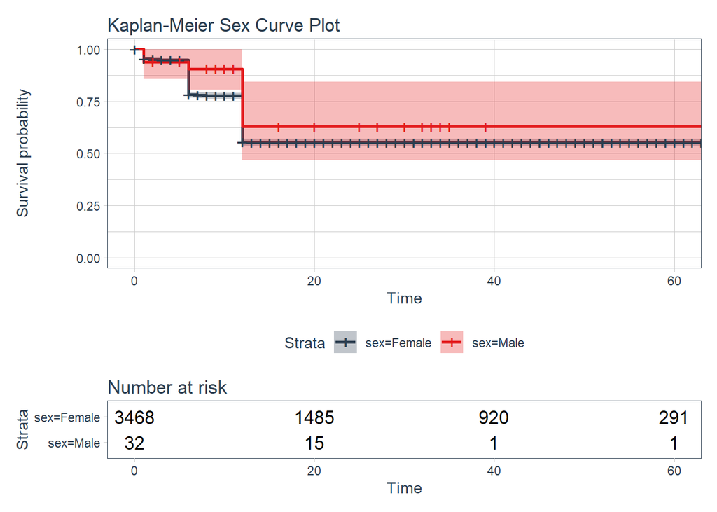

```r
library(tidyverse)
library(janitor)
library(tidyquant)
library(patchwork)
library(survival)
library(survminer)
library(dplyr)
library(knitr)
library(kableExtra)
library(MASS)
library(car)
library(Hmisc)
library(ggplot2)
library(flexsurv)
library(randomForestSRC)


data <- read.csv("breast_cancer_survival.csv")



#KM_SEX
sfit_sex<-survfit(Surv(time_to_event,event)~sex,data=data)
KM_sex<-ggsurvplot(
  sfit_sex,
  conf.int=TRUE,
  data=data,
  risk.table = TRUE
)

KM_sex_plot<-KM_sex$plot +
  theme_tq() +
  scale_fill_tq() +
  scale_color_tq() +
  labs(title="Kaplan-Meier Sex Curve Plot")

KM_sex_table<-KM_sex$table +
  theme_tq() +
  scale_fill_tq() +
  scale_color_tq() +
  theme(panel.grid = element_blank())

KM_sex_plot/KM_sex_table + plot_layout(heights=c(4,1))
```

```r
#Log-rank test sex
survdiff(Surv(time_to_event, event) ~ sex, data = data)
```

```
## Call:
## survdiff(formula = Surv(time_to_event, event) ~ sex, data = data)
##
##               N Observed Expected (O-E)^2/E (O-E)^2/V
## sex=Female 3468     1423   1419.7   0.00782      1.06
## sex=Male     32       10     13.3   0.83314      1.06
##
##  Chisq= 1.1  on 1 degrees of freedom, p= 0.3
```

```r
#Cox regression model sex
cox_sex <- coxph(Surv(time_to_event, event) ~ sex, data = data)
summary(cox_sex)
```

```
## Call:
## coxph(formula = Surv(time_to_event, event) ~ sex, data = data)
##
##   n= 3500, number of events= 1433
##
##            coef exp(coef) se(coef)      z Pr(>|z|)
## sexMale -0.3122    0.7318   0.3173 -0.984    0.325
##
##         exp(coef) exp(-coef) lower .95 upper .95
## sexMale    0.7318      1.366    0.3929     1.363
##
## Concordance= 0.502  (se = 0.001 )
## Likelihood ratio test= 1.08  on 1 df,   p=0.3
## Wald test            = 0.97  on 1 df,   p=0.3
## Score (logrank) test = 0.98  on 1 df,   p=0.3
```

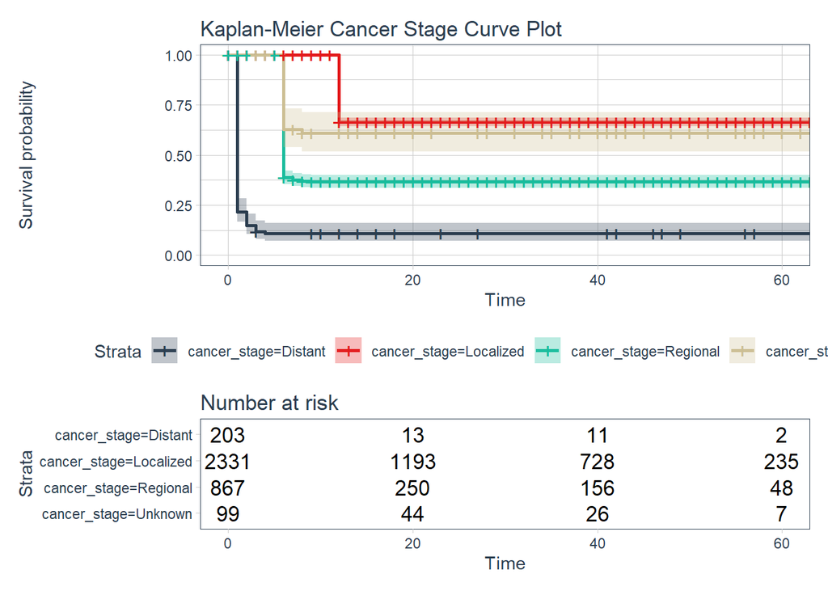

```r
#KM_CANCER STAGE
sfit_cancer_stage<-survfit(Surv(time_to_event,event)~cancer_stage,data=data)
KM_cancer_stage<-ggsurvplot(
  sfit_cancer_stage,
  conf.int=TRUE,
  data=data,
  risk.table = TRUE
)

KM_cancer_stage_plot<-KM_cancer_stage$plot +
  theme_tq() +
  scale_fill_tq() +
  scale_color_tq() +
  labs(title="Kaplan-Meier Cancer Stage Curve Plot")

KM_cancer_stage_table<-KM_cancer_stage$table +
  theme_tq() +
  scale_fill_tq() +
  scale_color_tq() +
  theme(panel.grid = element_blank())

KM_cancer_stage_plot/KM_cancer_stage_table + plot_layout(heights=c(2,1))
```

```r
#Log-rank test cancer_stage
survdiff(Surv(time_to_event, event) ~ cancer_stage, data = data)
```

```
## Call:
## survdiff(formula = Surv(time_to_event, event) ~ cancer_stage,
##     data = data)
##
##                           N Observed Expected (O-E)^2/E (O-E)^2/V
## cancer_stage=Distant    203      180     18.4  1.42e+03  1.70e+03
## cancer_stage=Localized 2331      689   1105.7  1.57e+02  8.83e+02
## cancer_stage=Regional   867      526    271.7  2.38e+02  3.75e+02
## cancer_stage=Unknown     99       38     37.1  1.96e-02  2.51e-02
##
##  Chisq= 2204  on 3 degrees of freedom, p= <2e-16
```

```r
#Cox regression model cancer_stage
cox_cancer_stage <- coxph(Surv(time_to_event, event) ~ cancer_stage, data = data)
summary(cox_cancer_stage)
```

```
## Call:
## coxph(formula = Surv(time_to_event, event) ~ cancer_stage, data = data)
##
##   n= 3500, number of events= 1433
##
##                           coef exp(coef) se(coef)      z Pr(>|z|)
## cancer_stageLocalized -3.00058   0.04976  0.08569 -35.02   <2e-16 ***
## cancer_stageRegional  -1.72863   0.17753  0.08787 -19.67   <2e-16 ***
## cancer_stageUnknown   -2.48964   0.08294  0.17933 -13.88   <2e-16 ***
## ---
## Signif. codes:  0 '***' 0.001 '**' 0.01 '*' 0.05 '.' 0.1 ' ' 1
##
##                       exp(coef) exp(-coef) lower .95 upper .95
## cancer_stageLocalized   0.04976     20.097   0.04207   0.05886
## cancer_stageRegional    0.17753      5.633   0.14944   0.21089
## cancer_stageUnknown     0.08294     12.057   0.05836   0.11787
##
## Concordance= 0.746  (se = 0.007 )
## Likelihood ratio test= 995.2  on 3 df,   p=<2e-16
## Wald test            = 1365  on 3 df,   p=<2e-16
## Score (logrank) test = 2161  on 3 df,   p=<2e-16
```

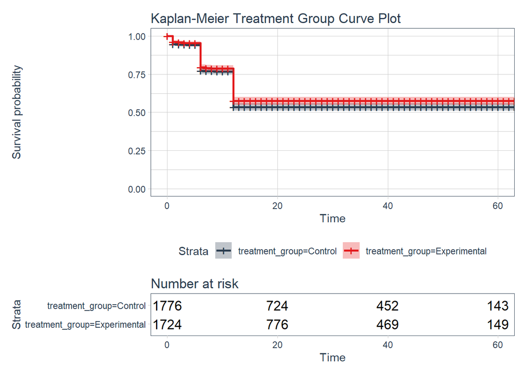

```r
#KM_treatment group
sfit_tg<-survfit(Surv(time_to_event,event)~treatment_group,data=data)
KM_tg<-ggsurvplot(
  sfit_tg,
  conf.int=TRUE,
  data=data,
  risk.table = TRUE
)

KM_tg_plot<-KM_tg$plot +
  theme_tq() +
  scale_fill_tq() +
  scale_color_tq() +
  labs(title="Kaplan-Meier Treatment Group Curve Plot")

KM_tg_table<-KM_tg$table +
  theme_tq() +
  scale_fill_tq() +
  scale_color_tq() +
  theme(panel.grid = element_blank())

KM_tg_plot/KM_tg_table + plot_layout(heights=c(4,1))
```

```r
#Log-rank test treatment_group
survdiff(Surv(time_to_event, event) ~ treatment_group, data = data)
```

```
## Call:
## survdiff(formula = Surv(time_to_event, event) ~ treatment_group,
##     data = data)
##
##                                 N Observed Expected (O-E)^2/E (O-E)^2/V
## treatment_group=Control      1776      760      721      2.14      5.43
## treatment_group=Experimental 1724      673      712      2.16      5.43
##
##  Chisq= 5.4  on 1 degrees of freedom, p= 0.02
```

```r
#Cox regression model treatment_group
cox_tg <- coxph(Surv(time_to_event, event) ~ treatment_group, data = data)
summary(cox_tg)
```

```
## Call:
## coxph(formula = Surv(time_to_event, event) ~ treatment_group,
##     data = data)
##
##   n= 3500, number of events= 1433
##
##                                 coef exp(coef) se(coef)      z Pr(>|z|)
## treatment_groupExperimental -0.12350   0.88382  0.05293 -2.333   0.0196 *
## ---
## Signif. codes:  0 '***' 0.001 '**' 0.01 '*' 0.05 '.' 0.1 ' ' 1
##
##                             exp(coef) exp(-coef) lower .95 upper .95
## treatment_groupExperimental    0.8838      1.131    0.7967    0.9804
##
## Concordance= 0.517  (se = 0.007 )
## Likelihood ratio test= 5.45  on 1 df,   p=0.02
## Wald test            = 5.44  on 1 df,   p=0.02
## Score (logrank) test = 5.45  on 1 df,   p=0.02
```

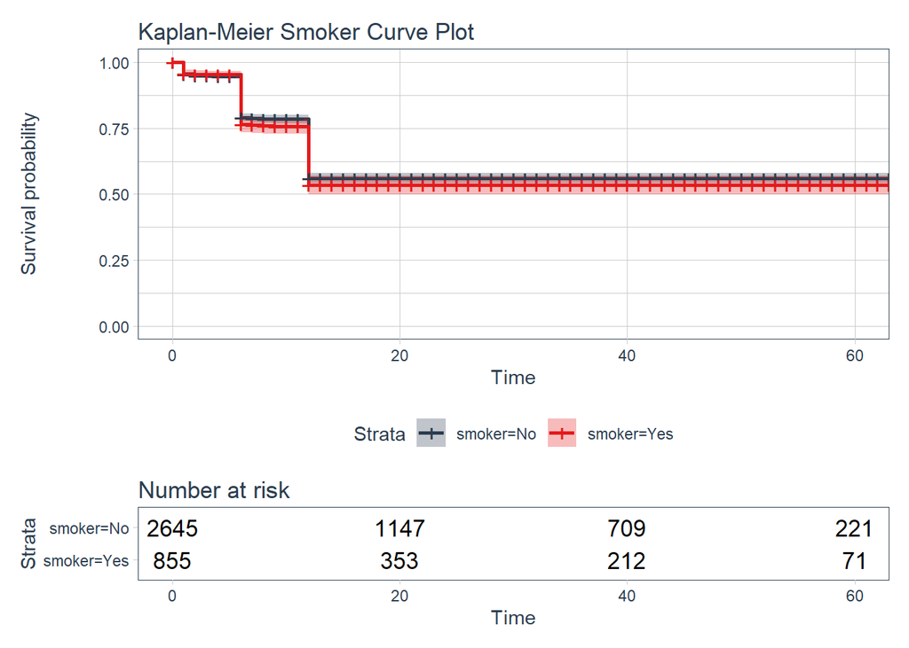

```r
#KM_smoker
sfit_smoker<-survfit(Surv(time_to_event,event)~smoker,data=data)
KM_smoker<-ggsurvplot(
  sfit_smoker,
  conf.int=TRUE,
  data=data,
  risk.table = TRUE
)

KM_smoker_plot<-KM_smoker$plot +
  theme_tq() +
  scale_fill_tq() +
  scale_color_tq() +
  labs(title="Kaplan-Meier Smoker Curve Plot")

KM_smoker_table<-KM_smoker$table +
  theme_tq() +
  scale_fill_tq() +
  scale_color_tq() +
  theme(panel.grid = element_blank())

KM_smoker_plot/KM_smoker_table + plot_layout(heights=c(4,1))
```

```r
#Log-rank test smoker
survdiff(Surv(time_to_event, event) ~ smoker, data = data)
```

```
## Call:
## survdiff(formula = Surv(time_to_event, event) ~ smoker, data = data)
##
##               N Observed Expected (O-E)^2/E (O-E)^2/V
## smoker=No  2645     1074     1093     0.347      1.85
## smoker=Yes  855      359      340     1.116      1.85
##
##  Chisq= 1.8  on 1 degrees of freedom, p= 0.2
```

```r
#Cox regression model smoker
cox_smoker <- coxph(Surv(time_to_event, event) ~ smoker, data = data)
summary(cox_smoker)
```

```
## Call:
## coxph(formula = Surv(time_to_event, event) ~ smoker, data = data)
##
##   n= 3500, number of events= 1433
##
##              coef exp(coef) se(coef)     z Pr(>|z|)
## smokerYes 0.08360   1.08719  0.06097 1.371     0.17
##
##           exp(coef) exp(-coef) lower .95 upper .95
## smokerYes     1.087     0.9198    0.9647     1.225
##
## Concordance= 0.509  (se = 0.006 )
## Likelihood ratio test= 1.85  on 1 df,   p=0.2
## Wald test            = 1.88  on 1 df,   p=0.2
## Score (logrank) test = 1.88  on 1 df,   p=0.2
```

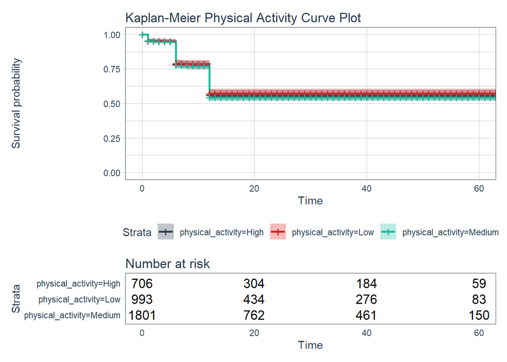

```r
#KM_physical activity
sfit_pa<-survfit(Surv(time_to_event,event)~physical_activity,data=data)
KM_pa<-ggsurvplot(
  sfit_pa,
  conf.int=TRUE,
  data=data,
  risk.table = TRUE
)

KM_pa_plot<-KM_pa$plot +
  theme_tq() +
  scale_fill_tq() +
  scale_color_tq() +
  labs(title="Kaplan-Meier Physical Activity Curve Plot")

KM_pa_table<-KM_pa$table +
  theme_tq() +
  scale_fill_tq() +
  scale_color_tq() +
  theme(panel.grid = element_blank())

KM_pa_plot/KM_pa_table + plot_layout(heights=c(3,1))
```

```r
#Log-rank test physical_activity
survdiff(Surv(time_to_event, event) ~ physical_activity, data = data)
```

```
## Call:
## survdiff(formula = Surv(time_to_event, event) ~ physical_activity,
##     data = data)
##
##                             N Observed Expected (O-E)^2/E (O-E)^2/V
## physical_activity=High    706      287      289    0.0199    0.0315
## physical_activity=Low     993      386      405    0.8902    1.5682
## physical_activity=Medium 1801      760      739    0.6193    1.6150
##
##  Chisq= 1.9  on 2 degrees of freedom, p= 0.4
```

```r
#Cox regression model physical_activity
cox_pa <- coxph(Surv(time_to_event, event) ~ physical_activity, data = data)
summary(cox_pa)
```

```
## Call:
## coxph(formula = Surv(time_to_event, event) ~ physical_activity,
##     data = data)
##
##   n= 3500, number of events= 1433
##
##                             coef exp(coef) se(coef)      z Pr(>|z|)
## physical_activityLow    -0.04270   0.95820  0.07794 -0.548    0.584
## physical_activityMedium  0.04320   1.04414  0.06928  0.623    0.533
##
##                         exp(coef) exp(-coef) lower .95 upper .95
## physical_activityLow       0.9582     1.0436    0.8225     1.116
## physical_activityMedium    1.0441     0.9577    0.9116     1.196
##
## Concordance= 0.51  (se = 0.008 )
## Likelihood ratio test= 1.95  on 2 df,   p=0.4
## Wald test            = 1.94  on 2 df,   p=0.4
## Score (logrank) test = 1.94  on 2 df,   p=0.4
```

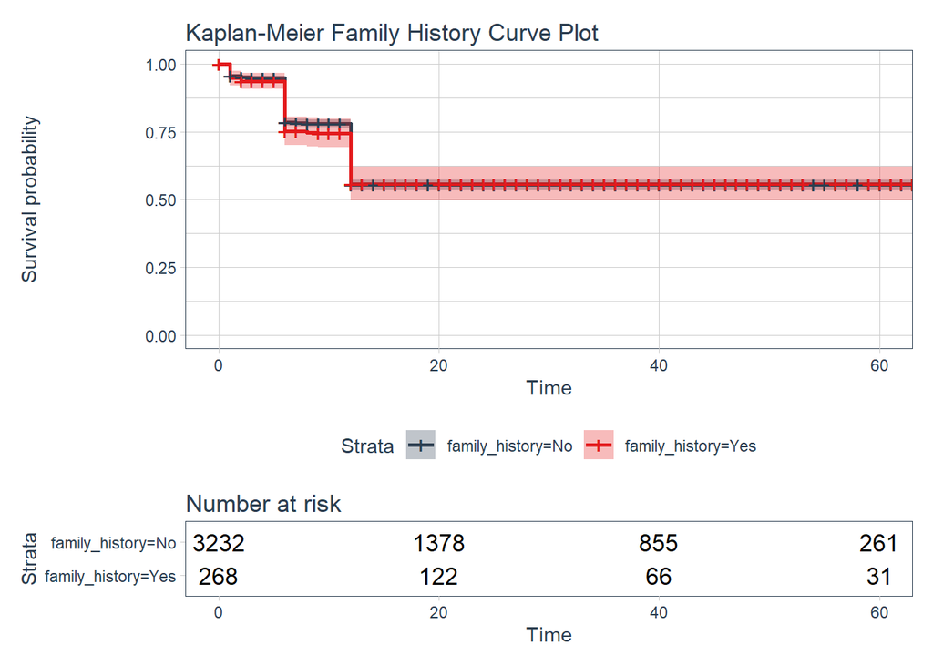

```r
#KM_family history
sfit_fh<-survfit(Surv(time_to_event,event)~family_history,data=data)
KM_fh<-ggsurvplot(
  sfit_fh,
  conf.int=TRUE,
  data=data,
  risk.table = TRUE
)

KM_fh_plot<-KM_fh$plot +
  theme_tq() +
  scale_fill_tq() +
  scale_color_tq() +
  labs(title="Kaplan-Meier Family History Curve Plot")

KM_fh_table<-KM_fh$table +
  theme_tq() +
  scale_fill_tq() +
  scale_color_tq() +
  theme(panel.grid = element_blank())

KM_fh_plot/KM_fh_table + plot_layout(heights=c(4,1))
```

```r
#Log-rank test family_history
survdiff(Surv(time_to_event, event) ~ family_history, data = data)
```

```
## Call:
## survdiff(formula = Surv(time_to_event, event) ~ family_history,
##     data = data)
##
##                       N Observed Expected (O-E)^2/E (O-E)^2/V
## family_history=No  3232     1321     1324   0.00695     0.115
## family_history=Yes  268      112      109   0.08447     0.115
##
##  Chisq= 0.1  on 1 degrees of freedom, p= 0.7
```

```r
#Cox regression model family_history
cox_fh <- coxph(Surv(time_to_event, event) ~ family_history, data = data)
summary(cox_fh)
```

```
## Call:
## coxph(formula = Surv(time_to_event, event) ~ family_history,
##     data = data)
##
##   n= 3500, number of events= 1433
##
##                      coef exp(coef) se(coef)    z Pr(>|z|)
## family_historyYes 0.02461   1.02492  0.09842 0.25    0.803
##
##                   exp(coef) exp(-coef) lower .95 upper .95
## family_historyYes     1.025     0.9757    0.8451     1.243
##
## Concordance= 0.502  (se = 0.004 )
## Likelihood ratio test= 0.06  on 1 df,   p=0.8
## Wald test            = 0.06  on 1 df,   p=0.8
## Score (logrank) test = 0.06  on 1 df,   p=0.8
```

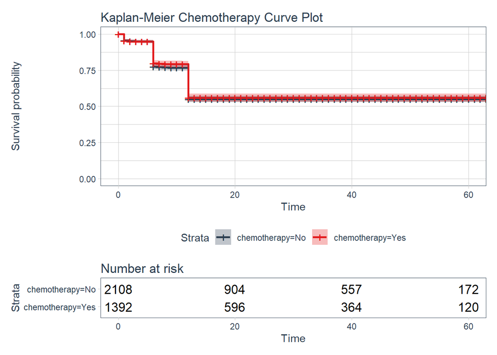

```r
#KM_chemotherapy
sfit_chemo<-survfit(Surv(time_to_event,event)~chemotherapy,data=data)
KM_chemo<-ggsurvplot(
  sfit_chemo,
  conf.int=TRUE,
  data=data,
  risk.table = TRUE
)

KM_chemo_plot<-KM_chemo$plot +
  theme_tq() +
  scale_fill_tq() +
  scale_color_tq() +
  labs(title="Kaplan-Meier Chemotherapy Curve Plot")

KM_chemo_table<-KM_chemo$table +
  theme_tq() +
  scale_fill_tq() +
  scale_color_tq() +
  theme(panel.grid = element_blank())

KM_chemo_plot/KM_chemo_table + plot_layout(heights=c(4,1))
```

```r
#Log-rank test chemotherapy
survdiff(Surv(time_to_event, event) ~ chemotherapy, data = data)
```

```
## Call:
## survdiff(formula = Surv(time_to_event, event) ~ chemotherapy,
##     data = data)
##
##                     N Observed Expected (O-E)^2/E (O-E)^2/V
## chemotherapy=No  2108      870      857     0.186     0.586
## chemotherapy=Yes 1392      563      576     0.278     0.586
##
##  Chisq= 0.6  on 1 degrees of freedom, p= 0.4
```

```r
#Cox regression model chemotherapy
cox_chemo <- coxph(Surv(time_to_event, event) ~ chemotherapy, data = data)
summary(cox_chemo)
```

```
## Call:
## coxph(formula = Surv(time_to_event, event) ~ chemotherapy, data = data)
##
##   n= 3500, number of events= 1433
##
##                     coef exp(coef) se(coef)      z Pr(>|z|)
## chemotherapyYes -0.03911   0.96164  0.05409 -0.723     0.47
##
##                 exp(coef) exp(-coef) lower .95 upper .95
## chemotherapyYes    0.9616       1.04    0.8649     1.069
##
## Concordance= 0.507  (se = 0.007 )
## Likelihood ratio test= 0.52  on 1 df,   p=0.5
## Wald test            = 0.52  on 1 df,   p=0.5
## Score (logrank) test = 0.52  on 1 df,   p=0.5
```

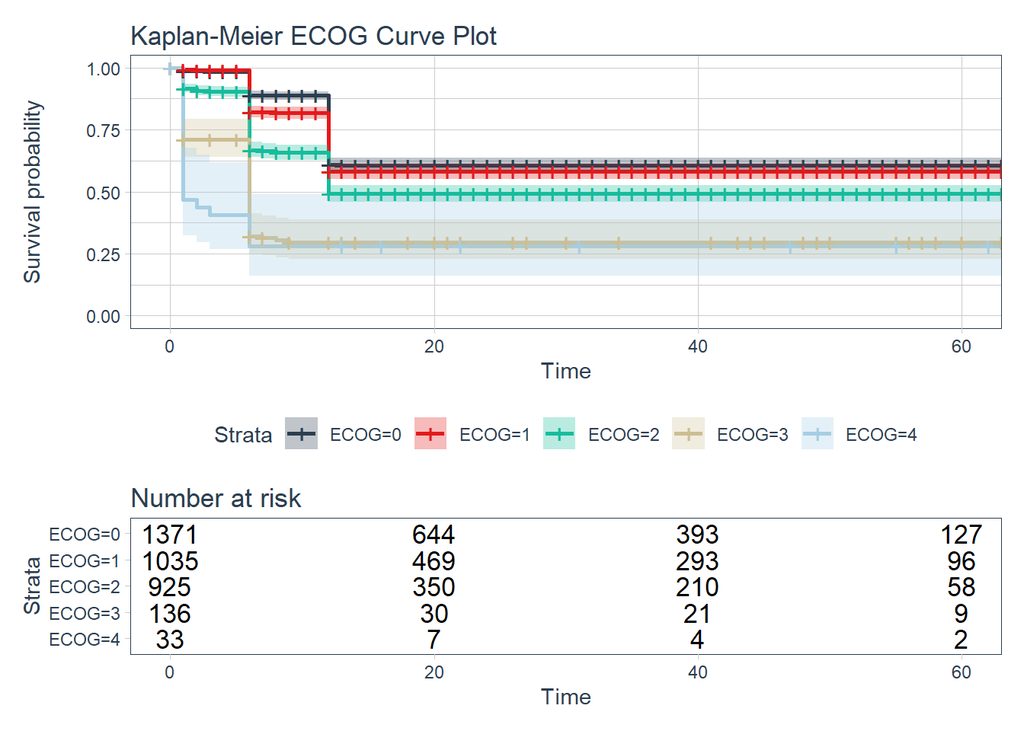

```r
#KM_ECOG
sfit_ECOG<-survfit(Surv(time_to_event,event)~ECOG,data=data)
KM_ECOG<-ggsurvplot(
  sfit_ECOG,
  conf.int=TRUE,
  data=data,
  risk.table = TRUE
)

KM_ECOG_plot<-KM_ECOG$plot +
  theme_tq() +
  scale_fill_tq() +
  scale_color_tq() +
  labs(title="Kaplan-Meier ECOG Curve Plot")

KM_ECOG_table<-KM_ECOG$table +
  theme_tq() +
  scale_fill_tq() +
  scale_color_tq() +
  theme(panel.grid = element_blank())

KM_ECOG_plot/KM_ECOG_table + plot_layout(heights=c(2,1))
```

```r
#Log-rank test ECOG
survdiff(Surv(time_to_event, event) ~ ECOG, data = data)
```

```
## Call:
## survdiff(formula = Surv(time_to_event, event) ~ ECOG, data = data)
##
##           N Observed Expected (O-E)^2/E (O-E)^2/V
## ECOG=0 1371      487   611.51     25.35     56.08
## ECOG=1 1035      395   441.49      4.89      8.95
## ECOG=2  925      435   339.93     26.59     43.92
## ECOG=3  136       93    33.60    104.98    131.65
## ECOG=4   33       23     6.47     42.23     52.12
##
##  Chisq= 253  on 4 degrees of freedom, p= <2e-16
```

```r
#Cox regression model ECOG
cox_ECOG <- coxph(Surv(time_to_event, event) ~ ECOG, data = data)
summary(cox_ECOG)
```

```
## Call:
## coxph(formula = Surv(time_to_event, event) ~ ECOG, data = data)
##
##   n= 3500, number of events= 1433
##
##         coef exp(coef) se(coef)     z Pr(>|z|)
## ECOG 0.33595   1.39927  0.02795 12.02   <2e-16 ***
## ---
## Signif. codes:  0 '***' 0.001 '**' 0.01 '*' 0.05 '.' 0.1 ' ' 1
##
##      exp(coef) exp(-coef) lower .95 upper .95
## ECOG     1.399     0.7147     1.325     1.478
##
## Concordance= 0.609  (se = 0.008 )
## Likelihood ratio test= 138.4  on 1 df,   p=<2e-16
## Wald test            = 144.5  on 1 df,   p=<2e-16
## Score (logrank) test = 146.4  on 1 df,   p=<2e-16
```

```r
#Cox regression model age
cox_age <- coxph(Surv(time_to_event, event) ~ age, data = data)
summary(cox_age)
```

```
## Call:
## coxph(formula = Surv(time_to_event, event) ~ age, data = data)
##
##   n= 3500, number of events= 1433
##
##          coef exp(coef)  se(coef)     z Pr(>|z|)
## age 0.0008078 1.0008081 0.0022508 0.359     0.72
##
##     exp(coef) exp(-coef) lower .95 upper .95
## age     1.001     0.9992    0.9964     1.005
##
## Concordance= 0.502  (se = 0.009 )
## Likelihood ratio test= 0.13  on 1 df,   p=0.7
## Wald test            = 0.13  on 1 df,   p=0.7
## Score (logrank) test = 0.13  on 1 df,   p=0.7
```

```r
#Cox regression model BMI
cox_BMI <- coxph(Surv(time_to_event, event) ~ BMI, data = data)
summary(cox_BMI)
```

```
## Call:
## coxph(formula = Surv(time_to_event, event) ~ BMI, data = data)
##
##   n= 3500, number of events= 1433
##
##          coef exp(coef)  se(coef)      z Pr(>|z|)
## BMI -0.002758  0.997246  0.004134 -0.667    0.505
##
##     exp(coef) exp(-coef) lower .95 upper .95
## BMI    0.9972      1.003    0.9892     1.005
##
## Concordance= 0.506  (se = 0.009 )
## Likelihood ratio test= 0.45  on 1 df,   p=0.5
## Wald test            = 0.45  on 1 df,   p=0.5
## Score (logrank) test = 0.45  on 1 df,   p=0.5
```

```r
#Cox regression model BMI_change_percent
cox_BMI_cp <- coxph(Surv(time_to_event, event) ~ BMI_change_percent, data = data)
summary(cox_BMI_cp)
```

```
## Call:
## coxph(formula = Surv(time_to_event, event) ~ BMI_change_percent,
##     data = data)
##
##   n= 3500, number of events= 1433
##
##                        coef exp(coef) se(coef)      z Pr(>|z|)
## BMI_change_percent -0.24924   0.77939  0.01254 -19.88   <2e-16 ***
## ---
## Signif. codes:  0 '***' 0.001 '**' 0.01 '*' 0.05 '.' 0.1 ' ' 1
##
##                    exp(coef) exp(-coef) lower .95 upper .95
## BMI_change_percent    0.7794      1.283    0.7605    0.7988
##
## Concordance= 0.673  (se = 0.009 )
## Likelihood ratio test= 368.8  on 1 df,   p=<2e-16
## Wald test            = 395.2  on 1 df,   p=<2e-16
## Score (logrank) test = 395.4  on 1 df,   p=<2e-16
```

```r
#Cox regression model BMI_change
cox_BMI_change <- coxph(Surv(time_to_event, event) ~ BMI_change, data = data)
summary(cox_BMI_change)
```

```
## Call:
## coxph(formula = Surv(time_to_event, event) ~ BMI_change, data = data)
##
##   n= 3500, number of events= 1433
##
##                 coef exp(coef)  se(coef)      z Pr(>|z|)
## BMI_change -0.010098  0.989953  0.004238 -2.383   0.0172 *
## ---
## Signif. codes:  0 '***' 0.001 '**' 0.01 '*' 0.05 '.' 0.1 ' ' 1
##
##            exp(coef) exp(-coef) lower .95 upper .95
## BMI_change      0.99       1.01    0.9818    0.9982
##
## Concordance= 0.525  (se = 0.009 )
## Likelihood ratio test= 5.69  on 1 df,   p=0.02
## Wald test            = 5.68  on 1 df,   p=0.02
## Score (logrank) test = 5.68  on 1 df,   p=0.02
```

```r
#Cox regression model tumor_size
cox_tumor <- coxph(Surv(time_to_event, event) ~ tumor_size, data = data)
summary(cox_tumor)
```

```
## Call:
## coxph(formula = Surv(time_to_event, event) ~ tumor_size, data = data)
##
##   n= 3500, number of events= 1433
##
##                coef exp(coef) se(coef)     z Pr(>|z|)
## tumor_size 0.242182  1.274026 0.009457 25.61   <2e-16 ***
## ---
## Signif. codes:  0 '***' 0.001 '**' 0.01 '*' 0.05 '.' 0.1 ' ' 1
##
##            exp(coef) exp(-coef) lower .95 upper .95
## tumor_size     1.274     0.7849     1.251     1.298
##
## Concordance= 0.686  (se = 0.009 )
## Likelihood ratio test= 491.5  on 1 df,   p=<2e-16
## Wald test            = 655.9  on 1 df,   p=<2e-16
## Score (logrank) test = 638.9  on 1 df,   p=<2e-16
```

```r
##Multivariable Cox regression
full_model <- coxph(Surv(time_to_event, event) ~ age + sex + cancer_stage +
                      treatment_group + BMI + BMI_change_percent +
                      tumor_size + smoker + physical_activity +
                      family_history + chemotherapy + ECOG, data = data)
vif(full_model)
```

```
##                        GVIF Df GVIF^(1/(2*Df))
## age                1.224910  1        1.106757
## sex                1.006049  1        1.003020
## cancer_stage       4.193124  3        1.269861
## treatment_group    1.014924  1        1.007434
## BMI                1.010840  1        1.005405
## BMI_change_percent 2.508724  1        1.583895
## tumor_size         2.393076  1        1.546957
## smoker             1.011540  1        1.005754
## physical_activity  1.035685  2        1.008804
## family_history     1.007827  1        1.003906
## chemotherapy       1.009104  1        1.004542
## ECOG               1.305385  1        1.142534
```

```r
step_model <- stepAIC(full_model, direction = "both")
```

```
## Start:  AIC=21415.01
## Surv(time_to_event, event) ~ age + sex + cancer_stage + treatment_group +
##     BMI + BMI_change_percent + tumor_size + smoker + physical_activity +
##     family_history + chemotherapy + ECOG
##
##                      Df   AIC
## - tumor_size          1 21413
## - BMI                 1 21413
## - ECOG                1 21413
## - chemotherapy        1 21413
## - sex                 1 21413
## - family_history      1 21414
## - age                 1 21414
## - BMI_change_percent  1 21414
## - physical_activity   2 21415
## <none>                  21415
## - smoker              1 21417
## - treatment_group     1 21421
## - cancer_stage        3 21772
##
## Step:  AIC=21413.01
## Surv(time_to_event, event) ~ age + sex + cancer_stage + treatment_group +
##     BMI + BMI_change_percent + smoker + physical_activity + family_history +
##     chemotherapy + ECOG
##
##                      Df   AIC
## - BMI                 1 21411
## - ECOG                1 21411
## - chemotherapy        1 21411
## - sex                 1 21411
## - family_history      1 21412
## - age                 1 21412
## - BMI_change_percent  1 21412
## - physical_activity   2 21413
## <none>                  21413
## - smoker              1 21415
## + tumor_size          1 21415
## - treatment_group     1 21419
## - cancer_stage        3 21954
##
```

[output cut: 138 more lines]

```
##
##                      Df   AIC
## <none>                  21402
## + physical_activity   2 21402
## + BMI_change_percent  1 21403
## + family_history      1 21403
## + age                 1 21404
## + chemotherapy        1 21404
## + sex                 1 21404
## + tumor_size          1 21404
## + ECOG                1 21404
## + BMI                 1 21404
## - smoker              1 21404
## - treatment_group     1 21410
## - cancer_stage        3 22398
```

```r
summary(step_model)
```

```
## Call:
## coxph(formula = Surv(time_to_event, event) ~ cancer_stage + treatment_group +
##     smoker, data = data)
##
##   n= 3500, number of events= 1433
##
##                                 coef exp(coef) se(coef)       z Pr(>|z|)
## cancer_stageLocalized       -3.01835   0.04888  0.08593 -35.126  < 2e-16 ***
## cancer_stageRegional        -1.74221   0.17513  0.08807 -19.781  < 2e-16 ***
## cancer_stageUnknown         -2.51339   0.08099  0.17947 -14.004  < 2e-16 ***
## treatment_groupExperimental -0.16443   0.84838  0.05299  -3.103  0.00192 **
## smokerYes                    0.12969   1.13848  0.06109   2.123  0.03376 *
## ---
## Signif. codes:  0 '***' 0.001 '**' 0.01 '*' 0.05 '.' 0.1 ' ' 1
##
##                             exp(coef) exp(-coef) lower .95 upper .95
## cancer_stageLocalized         0.04888    20.4575   0.04131   0.05785
## cancer_stageRegional          0.17513     5.7100   0.14737   0.20813
## cancer_stageUnknown           0.08099    12.3467   0.05698   0.11514
## treatment_groupExperimental   0.84838     1.1787   0.76468   0.94123
## smokerYes                     1.13848     0.8784   1.01000   1.28329
##
## Concordance= 0.754  (se = 0.008 )
## Likelihood ratio test= 1009  on 5 df,   p=<2e-16
## Wald test            = 1377  on 5 df,   p=<2e-16
## Score (logrank) test = 2174  on 5 df,   p=<2e-16
```

```r
#Best through AIC
full_model <- coxph(Surv(time_to_event, event) ~ cancer_stage + treatment_group + smoker, data = data)

step_model <- stepAIC(full_model, direction = "both")
```

```
## Start:  AIC=21402.01
## Surv(time_to_event, event) ~ cancer_stage + treatment_group +
##     smoker
##
##                   Df   AIC
## <none>               21402
## - smoker           1 21404
## - treatment_group  1 21410
## - cancer_stage     3 22398
```

```r
summary(step_model)    # Να δεις HR, CI, p-values
```

```
## Call:
## coxph(formula = Surv(time_to_event, event) ~ cancer_stage + treatment_group +
##     smoker, data = data)
##
##   n= 3500, number of events= 1433
##
##                                 coef exp(coef) se(coef)       z Pr(>|z|)
## cancer_stageLocalized       -3.01835   0.04888  0.08593 -35.126  < 2e-16 ***
## cancer_stageRegional        -1.74221   0.17513  0.08807 -19.781  < 2e-16 ***
## cancer_stageUnknown         -2.51339   0.08099  0.17947 -14.004  < 2e-16 ***
## treatment_groupExperimental -0.16443   0.84838  0.05299  -3.103  0.00192 **
## smokerYes                    0.12969   1.13848  0.06109   2.123  0.03376 *
## ---
## Signif. codes:  0 '***' 0.001 '**' 0.01 '*' 0.05 '.' 0.1 ' ' 1
##
##                             exp(coef) exp(-coef) lower .95 upper .95
## cancer_stageLocalized         0.04888    20.4575   0.04131   0.05785
## cancer_stageRegional          0.17513     5.7100   0.14737   0.20813
## cancer_stageUnknown           0.08099    12.3467   0.05698   0.11514
## treatment_groupExperimental   0.84838     1.1787   0.76468   0.94123
## smokerYes                     1.13848     0.8784   1.01000   1.28329
##
## Concordance= 0.754  (se = 0.008 )
## Likelihood ratio test= 1009  on 5 df,   p=<2e-16
## Wald test            = 1377  on 5 df,   p=<2e-16
## Score (logrank) test = 2174  on 5 df,   p=<2e-16
```

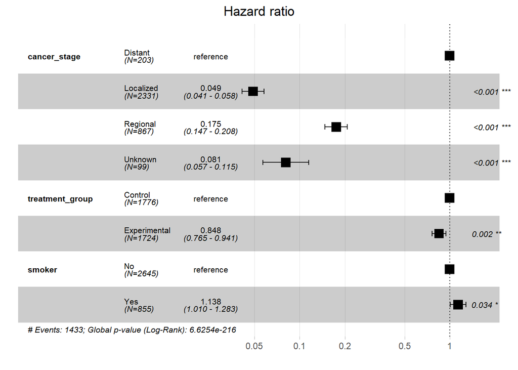

```r
ggforest(full_model, data = data)   # Forest plot για παρουσίαση
```

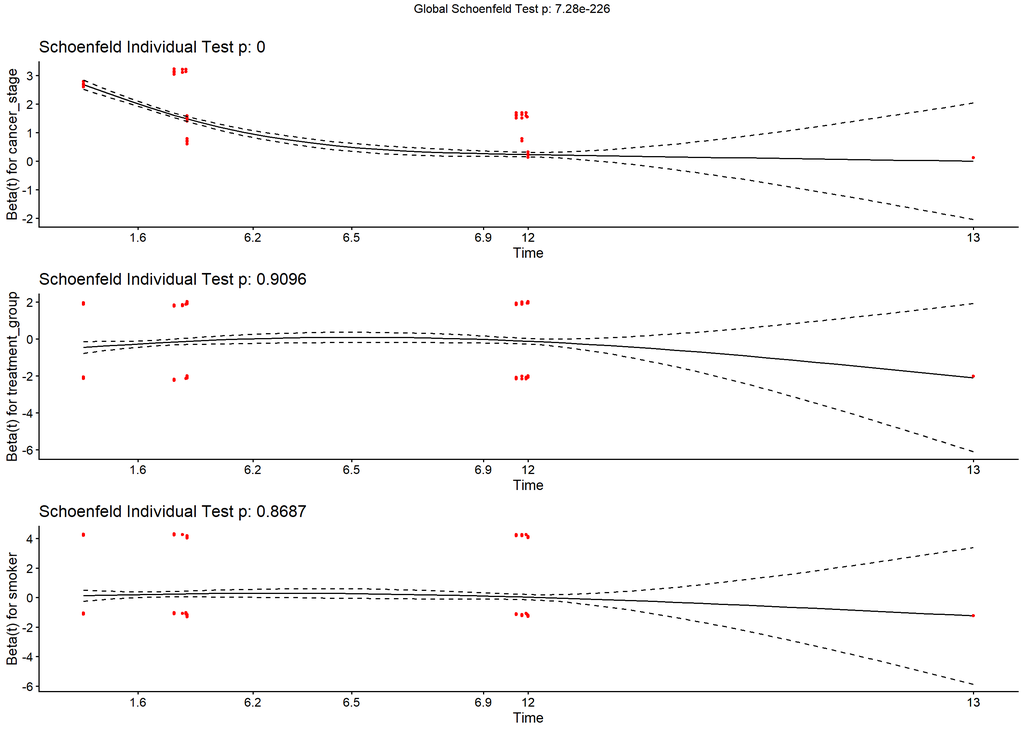

```r
ph_test <- cox.zph(full_model)
ggcoxzph(ph_test)
```

```r
# Cox με interaction
interaction_model <- coxph(Surv(time_to_event, event) ~ treatment_group * cancer_stage + smoker, data = data)
summary(interaction_model)
```

```
## Call:
## coxph(formula = Surv(time_to_event, event) ~ treatment_group *
##     cancer_stage + smoker, data = data)
##
##   n= 3500, number of events= 1433
##
##                                                       coef exp(coef) se(coef)
## treatment_groupExperimental                       -0.43200   0.64921  0.15061
## cancer_stageLocalized                             -3.16541   0.04220  0.11425
## cancer_stageRegional                              -1.87751   0.15297  0.11805
## cancer_stageUnknown                               -2.72315   0.06567  0.24054
## smokerYes                                          0.13068   1.13960  0.06113
## treatment_groupExperimental:cancer_stageLocalized  0.31210   1.36629  0.16884
## treatment_groupExperimental:cancer_stageRegional   0.28643   1.33166  0.17406
## treatment_groupExperimental:cancer_stageUnknown    0.46477   1.59165  0.35934
##                                                         z Pr(>|z|)
## treatment_groupExperimental                        -2.868  0.00413 **
## cancer_stageLocalized                             -27.706  < 2e-16 ***
## cancer_stageRegional                              -15.905  < 2e-16 ***
## cancer_stageUnknown                               -11.321  < 2e-16 ***
## smokerYes                                           2.138  0.03252 *
## treatment_groupExperimental:cancer_stageLocalized   1.848  0.06453 .
## treatment_groupExperimental:cancer_stageRegional    1.646  0.09986 .
## treatment_groupExperimental:cancer_stageUnknown     1.293  0.19587
## ---
## Signif. codes:  0 '***' 0.001 '**' 0.01 '*' 0.05 '.' 0.1 ' ' 1
##
##                                                   exp(coef) exp(-coef)
## treatment_groupExperimental                         0.64921     1.5403
## cancer_stageLocalized                               0.04220    23.6984
## cancer_stageRegional                                0.15297     6.5372
## cancer_stageUnknown                                 0.06567    15.2282
## smokerYes                                           1.13960     0.8775
## treatment_groupExperimental:cancer_stageLocalized   1.36629     0.7319
## treatment_groupExperimental:cancer_stageRegional    1.33166     0.7509
## treatment_groupExperimental:cancer_stageUnknown     1.59165     0.6283
##                                                   lower .95 upper .95
## treatment_groupExperimental                         0.48326   0.87214
## cancer_stageLocalized                               0.03373   0.05279
## cancer_stageRegional                                0.12137   0.19279
## cancer_stageUnknown                                 0.04098   0.10522
## smokerYes                                           1.01094   1.28465
## treatment_groupExperimental:cancer_stageLocalized   0.98136   1.90221
## treatment_groupExperimental:cancer_stageRegional    0.94674   1.87308
## treatment_groupExperimental:cancer_stageUnknown     0.78701   3.21896
##
## Concordance= 0.752  (se = 0.008 )
## Likelihood ratio test= 1013  on 8 df,   p=<2e-16
## Wald test            = 1395  on 8 df,   p=<2e-16
## Score (logrank) test = 2250  on 8 df,   p=<2e-16
```

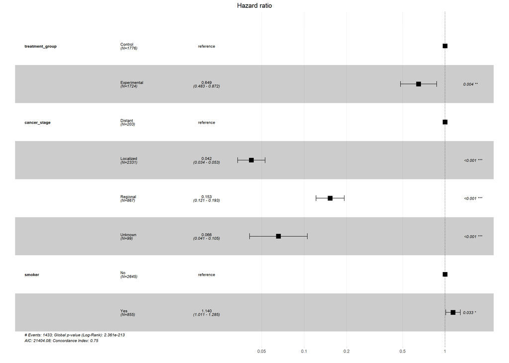

```r
# Forest plot για interaction
ggforest(interaction_model, data = data)
```

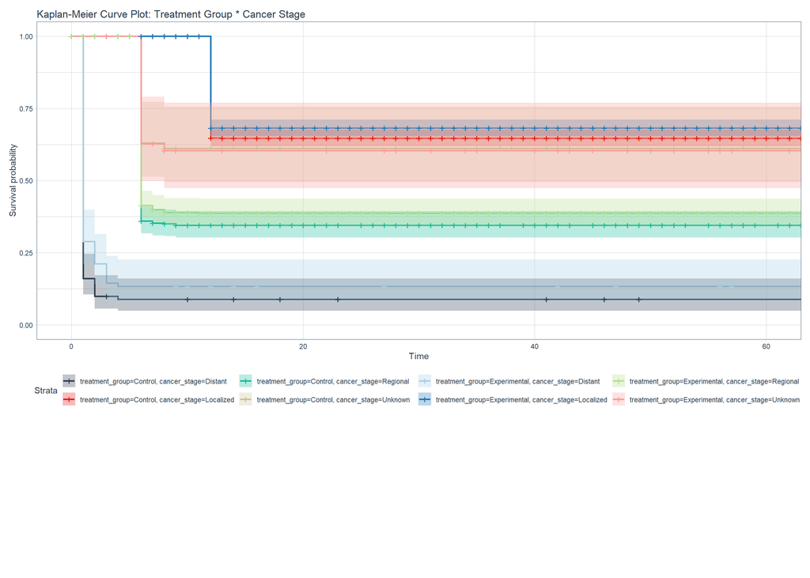

```r
# Kaplan-Meier για interaction treatment_group * cancer_stage
sfit_interaction <- survfit(Surv(time_to_event, event) ~ treatment_group + cancer_stage, data = data)

KM_interaction <- ggsurvplot(
  sfit_interaction,
  conf.int = TRUE,
  data = data,
  palette = "Dark2"
)

KM_interaction_plot <- KM_interaction$plot +
  theme_tq() +
  scale_fill_tq() +
  scale_color_tq() +
  labs(title = "Kaplan-Meier Curve Plot: Treatment Group * Cancer Stage")
KM_interaction_table <- KM_interaction$table +
  theme_tq() +
  scale_fill_tq() +
  scale_color_tq() +
  theme(panel.grid = element_blank())

KM_interaction_plot / KM_interaction_table + plot_layout(heights = c(2,1))
```

```r
# Φιλτράρουμε δεδομένα γιατί AFT δεν δέχεται 0 στον χρόνο επιβίωσης
data_aft <- data %>% filter(time_to_event > 0) %>%
  mutate_if(is.character, as.factor)

#Accelerated Failure Time (AFT) model – log-logistic
aft_model_ll <- survreg(
  Surv(time_to_event, event) ~ cancer_stage + treatment_group + smoker,
  data = data_aft,
  dist = "loglogistic"
)
summary(aft_model_ll)
```

```
##
## Call:
## survreg(formula = Surv(time_to_event, event) ~ cancer_stage +
##     treatment_group + smoker, data = data_aft, dist = "loglogistic")
##                               Value Std. Error     z      p
## (Intercept)                  0.2476     0.0920  2.69 0.0072
## cancer_stageLocalized        3.7781     0.0967 39.09 <2e-16
## cancer_stageRegional         2.2626     0.1011 22.38 <2e-16
## cancer_stageUnknown          3.1413     0.1992 15.77 <2e-16
## treatment_groupExperimental  0.1505     0.0566  2.66 0.0079
## smokerYes                   -0.0734     0.0650 -1.13 0.2593
## Log(scale)                  -0.2025     0.0224 -9.06 <2e-16
##
## Scale= 0.817
##
## Log logistic distribution
## Loglik(model)= -6414.5   Loglik(intercept only)= -7002.1
##  Chisq= 1175.22 on 5 degrees of freedom, p= 6.9e-252
## Number of Newton-Raphson Iterations: 4
## n= 3471
```

```r
# Μετατροπή συντελεστών σε Time Ratios
exp(coef(aft_model_ll))
```

```
##                 (Intercept)       cancer_stageLocalized
##                   1.2808877                  43.7350099
##        cancer_stageRegional         cancer_stageUnknown
##                   9.6084398                  23.1340507
## treatment_groupExperimental                   smokerYes
##                   1.1624015                   0.9292526
```

```r
# Random Survival Forest (Machine Learning)
rf_model <- rfsrc(
  Surv(time_to_event, event) ~ cancer_stage + treatment_group + smoker + BMI + ECOG,
  data = data_aft,
  ntree = 1000,
  importance = TRUE
)

# Variable importance
rf_model$importance
```

```
##    cancer_stage treatment_group          smoker             BMI            ECOG
##     0.296258287    -0.002280802    -0.006037405    -0.004576016     0.015248254
```

```r
# Predicted survival for first 10 patients
predict(rf_model, newdata = data_aft[1:10, ])
```

```
##   Sample size of test (predict) data: 10
##                 Number of grow trees: 1000
##   Average no. of grow terminal nodes: 157.902
##          Total no. of grow variables: 5
##        Resampling used to grow trees: swor
##     Resample size used to grow trees: 2194
##                             Analysis: RSF
##                               Family: surv
##                                 CRPS: 1.5718196
##                          stand. CRPS: 0.1209092
##          Requested performance error: 0.64285714
```